# BCB420 Assignment 1

Justin Chee, 1002475136

## Dataset

**GEO ID:** GSE111972

**Dataset Name:** Transcriptional profiling of human microglia reveals grey-white matter heterogeneity and multiple sclerosis-associated changes

## Dataset Overview

GEO dataset was downloaded during the setup of the page.

Previously I had the opportunity to work with RNAseq data from brain samples and it was very interesting to examine the different expression profiles between different cell types in the brain especially in a diseased state. This dataset examines the expression profiles of both the grey matter and white matter of the human microglia in both healthy donors as well as donors with Multiple Sclerosis.

```r
head(Meta(GSE))
```

```
## $contact_address
## [1] "Carl-Troll-Strasse 31"
##
## $contact_city
## [1] "Bonn"
##
## $contact_country
## [1] "Germany"
##
## $contact_department
## [1] "Genomics and Immunoregulation"
##
## $contact_email
## [1] "j.schultze@uni-bonn.de"
##
## $contact_institute
## [1] "LIMES (Life and Medical Sciences Center Genomics and Immunoregulation)"
```

**Title:** Illumina NextSeq 500 (Homo sapiens)

**Technology:** high-throughput sequencing

**Submission Date:** Apr 15 2014

**Last Update Date:** Mar 26 2019

**Organism:** Homo sapiens

**Number of GEO datasets that use this technology:** 2928

**Number of GEO samples that use this technology:** 132407

```r
colnames(MS_exp)[2:32]
```

```
##  [1] "Sample_CON_GM_1"  "Sample_CON_WM_2"  "Sample_CON_GM_2"
##  [4] "Sample_CON_WM_5"  "Sample_CON_GM_3"  "Sample_CON_WM_7"
##  [7] "Sample_CON_GM_4"  "Sample_CON_WM_9"  "Sample_CON_GM_5"
## [10] "Sample_CON_WM_11" "Sample_CON_WM_1"  "Sample_CON_WM_10"
## [13] "Sample_CON_WM_3"  "Sample_CON_WM_4"  "Sample_CON_WM_6"
## [16] "Sample_CON_WM_8"  "Sample_MS_GM_1"   "Sample_MS_WM_2"
## [19] "Sample_MS_GM_3"   "Sample_MS_WM_5"   "Sample_MS_GM_4"
## [22] "Sample_MS_WM_6"   "Sample_MS_GM_5"   "Sample_MS_WM_10"
## [25] "Sample_MS_GM_6"   "Sample_MS_WM_11"  "Sample_MS_WM_1"
## [28] "Sample_MS_WM_3"   "Sample_MS_WM_7"   "Sample_MS_WM_8"
## [31] "Sample_MS_WM_9"
```

Each sample is the RNAseq data from the microglia cells of an individual test subject. 15 samples (5 grey matter, 10 white matter) were from 10 donors affected with Multiple Sclerosis and 16 samples (5 grey matter, 11 white matter) were from 11 control (healthy) donors.

`CON_GM` = Control, grey matter

`CON_WM` = control, white matter

`MS_GM` = Multiple Sclerosis, grey matter

`MS_WM` = Multiple Sclerosis, white matter

## Cleaning Dataset

**Number of genes with measurements:** 21283

```r
# listing number of times Gene IDs appear in row names
kable(sort(table(MS_exp$ID), decreasing = TRUE)[1:10])
```

| Var1 | Freq |
| --- | --- |
| A1BG | 1 |
| A1BG-AS1 | 1 |
| A2M | 1 |
| A2M-AS1 | 1 |
| A2ML1 | 1 |
| A2MP1 | 1 |
| A3GALT2 | 1 |
| A4GALT | 1 |
| A4GNT | 1 |
| AAAS | 1 |

Since all Gene IDs only appear in the count table once, the number of unique genes in this dataset is: 21283. This also suggests that all rows in this data are genes.

**Filtering out weakly expressed genes:**

```r
counts <- cpm(MS_exp[, 2:32])
rownames(counts) <- MS_exp$ID
kable(counts[1:10, 1:5])
```

|  | Sample_CON_GM_1 | Sample_CON_WM_2 | Sample_CON_GM_2 | Sample_CON_WM_5 | Sample_CON_GM_3 |
| --- | --- | --- | --- | --- | --- |
| A1BG | 2.799116 | 0.000000 | 0.000000 | 7.8594571 | 4.498186 |
| A1BG-AS1 | 0.000000 | 0.000000 | 2.599003 | 2.1960289 | 2.201245 |
| A2M | 2862.673601 | 1948.027629 | 2083.136636 | 1700.0145643 | 1834.013816 |
| A2M-AS1 | 54.646420 | 22.284590 | 6.339038 | 1.8492889 | 8.374271 |
| A2ML1 | 0.000000 | 0.000000 | 0.000000 | 0.6934845 | 0.000000 |
| A2MP1 | 0.000000 | 0.000000 | 1.965103 | 0.0000000 | 0.000000 |
| A3GALT2 | 5.789085 | 0.000000 | 0.000000 | 0.0000000 | 0.000000 |
| A4GALT | 0.000000 | 0.000000 | 0.000000 | 0.6934845 | 1.196325 |
| A4GNT | 0.000000 | 2.998539 | 0.000000 | 0.0000000 | 0.000000 |
| AAAS | 48.157569 | 2.317052 | 42.471526 | 22.8849471 | 22.012447 |

```r
strong_exp <- rowSums(counts > 1) >= 3
MS_exp_filter <- MS_exp[strong_exp, ]
dim(MS_exp) - dim(MS_exp_filter)
```

```
## [1] 3834    0
```

As we can see this process filtered out 3834 gene IDs that were weakly expressed.

**Mapping to HUGO identifiers**

```r
rownames(MS_exp)[1:18]
```

```
##  [1] "A1BG"     "A1BG-AS1" "A2M"      "A2M-AS1"  "A2ML1"    "A2MP1"
##  [7] "A3GALT2"  "A4GALT"   "A4GNT"    "AAAS"     "AACS"     "AACSP1"
## [13] "AADAC"    "AADACL4"  "AADACP1"  "AADAT"    "AAED1"    "AAGAB"
```

As we can see the rows in this count matrix are already mapped to HUGO gene IDs so no further mapping is required. Therefore no further processing regarding non-mapped rows or mulitple row mappings is required. Coverage of this dataset is also 100% for HUGO identifiers since all rows already use HUGO IDs.

## Normalizing Dataset

**Note:** The datafile retrieved from GEO appears to already be normalized, however as a proof of concept, data will be normalized again.

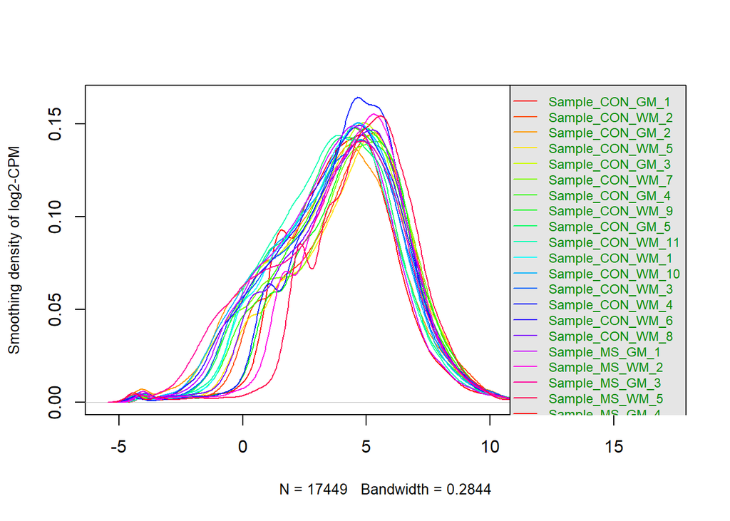

```r
# Based on Lecture Material using TMM method

# prepping boxplot data
MS_data_plot <- log2(cpm(MS_exp_filter[,2:32]))

# prepping data for density plot
counts_density <- apply(log2(cpm(MS_exp_filter[,3:22])), 2, density)

xlim <- 0; ylim <- 0

for (i in 1:length(counts_density)) {
  xlim <- range(c(xlim, counts_density[[i]]$x));
  ylim <- range(c(ylim, counts_density[[i]]$y))
}

cols <- rainbow(length(counts_density))
ltys <- rep(1, length(counts_density))

#plot the first density plot to initialize the plot
plot(counts_density[[1]], xlim=xlim, ylim=ylim, type="n",
      ylab="Smoothing density of log2-CPM", main="", cex.lab = 0.85)

#plot each line
for (i in 1:length(counts_density)) lines(counts_density[[i]], col=cols[i], lty=ltys[i])

#create legend
legend("topright", colnames(MS_data_plot),
        col=cols, lty=ltys, cex=0.75,
        border ="blue",  text.col = "green4",
        merge = TRUE, bg = "gray90")
```

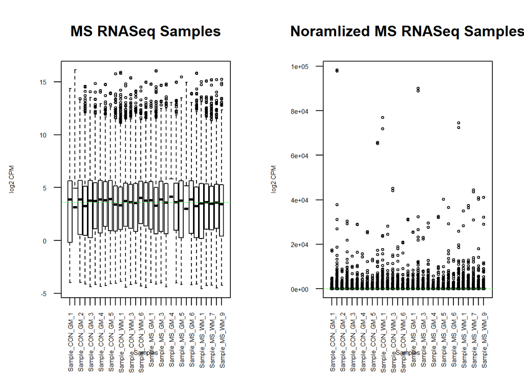

```r
# prepping normalized data
filter_data_matrix <- as.matrix(MS_exp_filter[,2:32])
rownames(filter_data_matrix) <- MS_exp_filter$ID
norm = DGEList(counts=filter_data_matrix, group=colnames(MS_exp_filter)[2:32])
norm = calcNormFactors(norm)
normalized_counts <- cpm(norm)

# plotting raw and normalized boxplot data
options(warn = -1)

par(mfrow=c(1,2))

boxplot(MS_data_plot, xlab = "Samples", ylab = "log2 CPM",
        las = 2, cex = 0.5, cex.lab = 0.5,
        cex.axis = 0.5, main = "MS RNASeq Samples")
abline(h = median(apply(MS_data_plot, 2, median)), col = "green",
       lwd = 0.6, lty = "dashed")

boxplot(normalized_counts, xlab = "Samples", ylab = "log2 CPM",
        las = 2, cex = 0.5, cex.lab = 0.5,
        cex.axis = 0.5, main = "Noramlized MS RNASeq Samples")
abline(h = median(apply(normalized_counts, 2, median)), col = "green",
       lwd = 0.6, lty = "dashed")
```

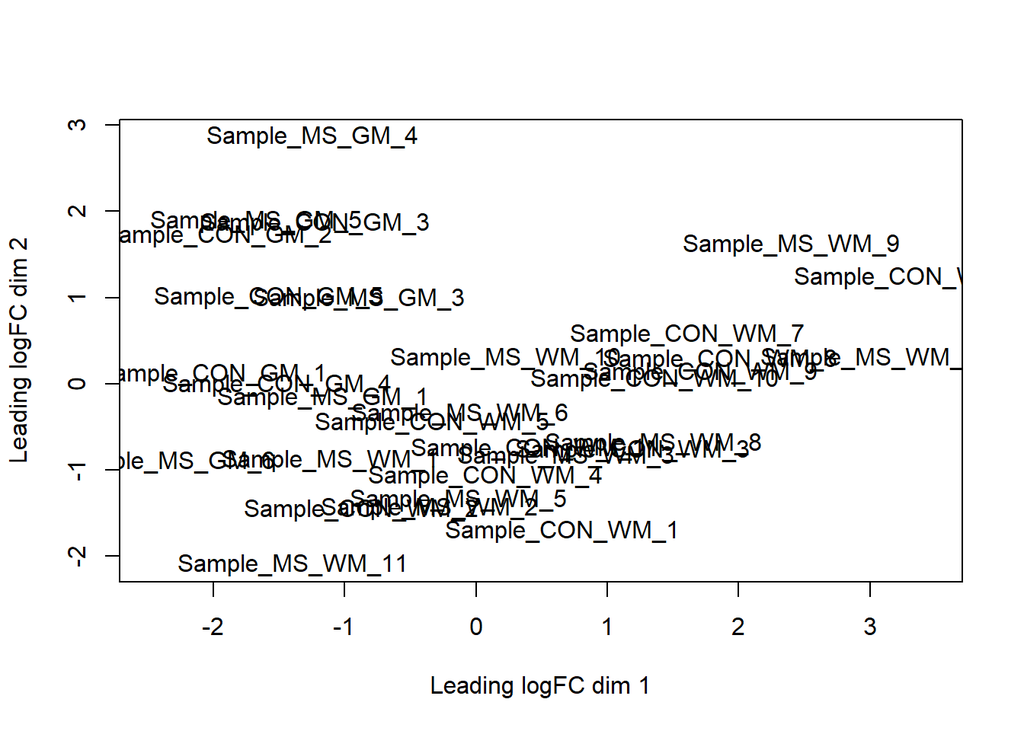

```r
# MDS plot
par(mfrow=c(1,1))

plotMDS(norm, labels=colnames(MS_exp_filter)[2:32])
```

## Final Processed Expression Data

`MS_exp_filter`